# ECS230 Hw3

Eric Kalosa-Kenyon

15 November 2017

Abstract

In this assignment, I time matrix multiplications to assess processor performance in basic linear algebra operations.

# Matrix multiplication

Developed here are three methods for assessing processor and algorithm performance. First, a simple matrix multiplication algorithm written in C is assessed for number of clock cycles elapsed over execution with square matrices of size 100, 200, 500, 1000, and 2000 doubles each. Next, all six loop orderings for the simple matrix multiplication algorithm, discussed in more detail below, are considered. Finally, the standard BLAS dgemm function is used to benchmark the preceeding algorithms.

## Matrix multiplication performance

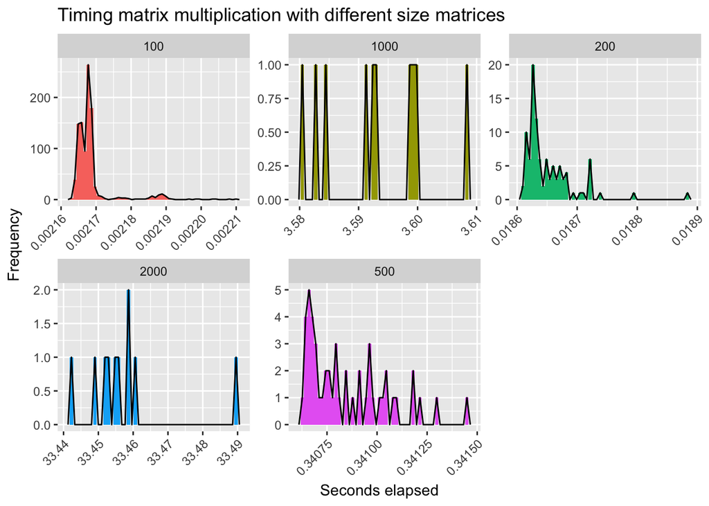

## Loop rearrangement

Matrix multiplication is defined as follows (for n by n real matrices):
$$A_{n\times n} B_{n\times n} = C_{n\times n} = (c_{i,j})_{1\le i, j\le n} =
(\sum_{k=1}^n a_{i, k} b_{k, j}) =
(\langle \vec{a_i^\top}, \vec{b_j} \rangle )_{1\le i,j\le n}$$
The question naturally arises: which index should come first in a looping matrix multiplication algorithm? This section is an attempt to answer that question.

Using column-major ordering (i.e. $i + n*j$) for array indexing into the $i$th row and $j$th column, the following experiment times different orderings of the embedded for loops used to calculate the matrix product. A typical ordering may look like the following:

```
sum = 0
for(i in 1:n){
    for(j in 1:n){
        for(k in 1:n){
             sum += A[i + k*n] * B[k + i*n]
        }
        C[i + n*j] = sum
        sum = 0
    }
}
```

Each of the loop orderings is a permutation of the i, j, and k loops in the above snippet.

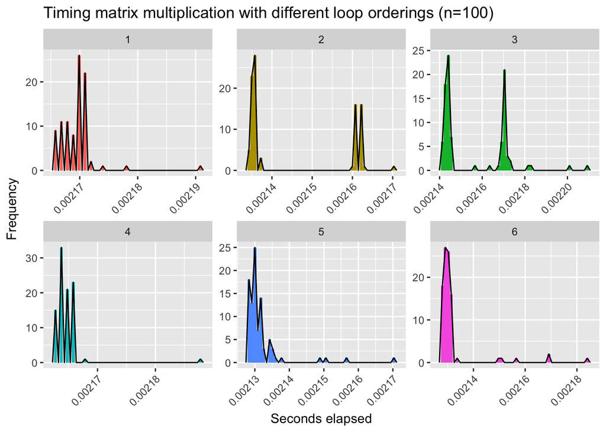

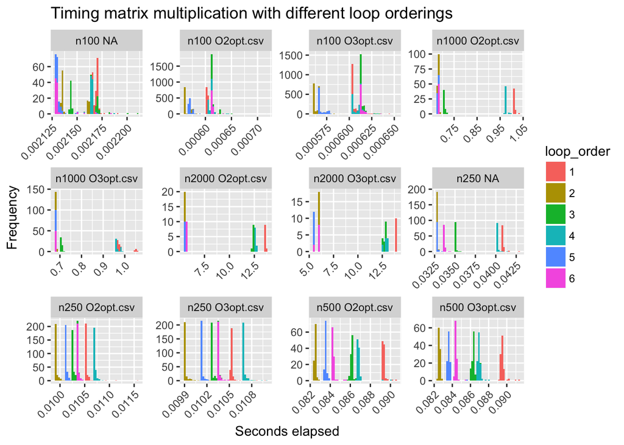

The loop orderings are as follows, using column-major indexing: 1. jik 2. jki 3. ijk 4. ikj 5. kji 6. kij

## Using BLAS dgemm()

There are many more optimizations possible for the matrix multiplication algorithm beyond simply using the most effective loop ordering. The mature BLAS linear algebra package available in C implements a screaming fast matrix multiplication function titled dgemm(). The results of timing the dgemm() algorithm follow:

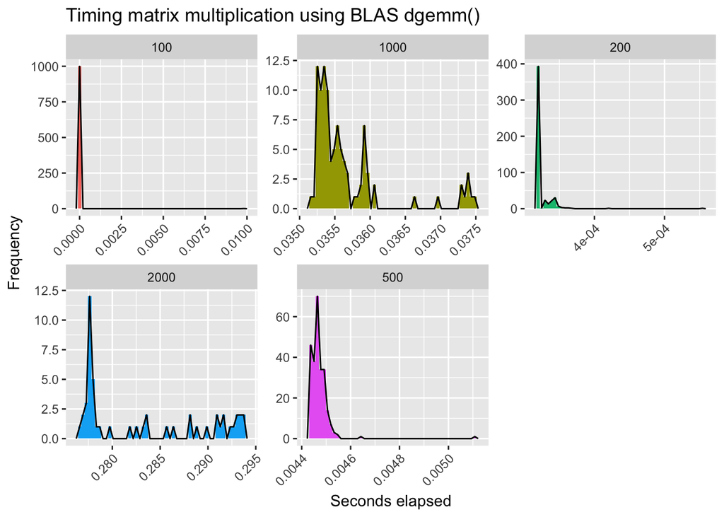

One can see that, in addition to being much faster than the simple implementation presented in the preceeding sections, the dgemm() multiplication has a lower spread of results. The take-away here is that one should, in production settings, rely on the BLAS rather than custom matrix multiplication algorithms.

## Comments on performance

Among many available speedups, there were no attempts to make use of block structures in this multiplication. The result of this negligance is that once the size of the matrix exceeds the size of the processor’s L1 cache, the speed of computation is massively reduced.

### Gflop/sec performance measurement

The number of flops theoretically required to perform a basic matrix multiplication is $2n^3$. The $2$ is due to the addition and multiplication in $s = s + a_{i,k}b_{k,j}$ and the $n^3$ is due to the three embedded for loops.

### Peak performance

The peak performance of a 4.0 GHz processor depends on a number of factors, including but not limited to SMID registers, fused add-multiply, hyperthreading, and “turbo boost”.

Depending on the aforementioned factors, the typical number of flops per clock cycle is between 1 and 4. The processor’s advertised speed is $4*10^9$ cycles per second. Hence, a reasonable estimate for processor performance is between 4 and 16 Gflops/sec.

Fused add-multiply can cut the number of flops required in the `sum = sum + a*b` step down from 2 to 1. This would reduce the number of flops required for matrix multiplication from $2n^3$ to $n^3$. Due to the embarassingly parallelizable nature of the algorithm, hyperthreading and multiple cores can potentially increase the number of flops/sec possible on the i7 processor. Without parallelization, the overclocking turbo-boost feature of the processor may increase the cycles/sec of a single core beyond its advertised speed. Finally, SMID (https://en.wikipedia.org/wiki/SIMD) allows multiple data to be acted on by the same opperator. Among many obvious and sophisticated uses of SMID in matrix algorithms, singly applying the operator $\langle\cdot, B_{:,j}\rangle$ identically to every row in $A$ would, in an ideal case, cut the number of flops required in the algorithm by a factor of $n$.

Certianly, these and other optimizations are implemented in the BLAS package, and the speedup they bring is immediately apparent upon timing an unsophisticated matrix multiplication algorithm.

# Source code

Please note that the following source is a Frankenstein work, and the sources referenced in the header were hugely helpful. Furthermore, the code handed in on the CSIF computers is slightly different from the following source - the handed in code conforms to the specifications of the assignment, wheras the following source is the code used to time matrix multiplications in the first section. Timings in subsequent sections were performed using similar code, not worth reproducing here for brevity.

```
// Author: Eric Kalosa-Kenyon
//
// This program times matrix multiplication and reports results.
// Takes:
//      n - command line input, size of matrices to multiply
//      r - command line input, number of times to perform this multiplication
// Returns:
//      stdio - timing results
//
// Sources:
//  1. http://www.programmingsimplified.com/c-program-multiply-matrices
//  2. https://en.wikipedia.org/wiki/C_dynamic_memory_allocation
//  3. http://web.cs.ucdavis.edu/~fgygi/ecs230/homework/hw3/dotblas.c
//  4. http://web.cs.ucdavis.edu/~fgygi/ecs230/homework/hw2/timing1.c
//  5. http://www.cplusplus.com/forum/windows/192252/

#include "stdio.h"
#include "stdlib.h"
#include "time.h"
#include "sys/time.h"
#include "math.h"

// BEGIN SUBROUTINES
long long readTSC(void)
{
  /* Read the time stamp counter on Intel x86 chips */
  /* Directly from timing2.c on ~fgygi */
  /* http://web.cs.ucdavis.edu/~fgygi/ecs230/homework/hw2/timing2.c */
  union { long long complete; unsigned int part[2]; } ticks;
  __asm__ ("rdtsc; mov %%eax,%0;mov %%edx,%1"
    : "=mr" (ticks.part[0]), "=mr" (ticks.part[1])
    : /* no inputs */
    : "eax", "edx");
  return ticks.complete;
}
// END SUBROUTINES

// BEGIN MAIN
int main(int argc, char** argv)
{
```

[output cut: 45 more lines]

```
        }
    }

    // determine and display timing results
    stop = readTSC();
    t_cpu = stop - start;
    t_real = t_cpu / cpu_speed;

    printf("%ld, %f\n", t_cpu, t_real );

  } // END for loop over R (multiply AB multiple times)

  return 0;
}
// END MAIN
```